# Analiza danych tranzakcyjnych Allegro z dnia 3 kwietnia 2016 r.

Bogdan Jastrzębski

07 - 03 - 2019

# 0. Dane i ich poprawność

Na początku przyjżymy się zbiorowi danych.

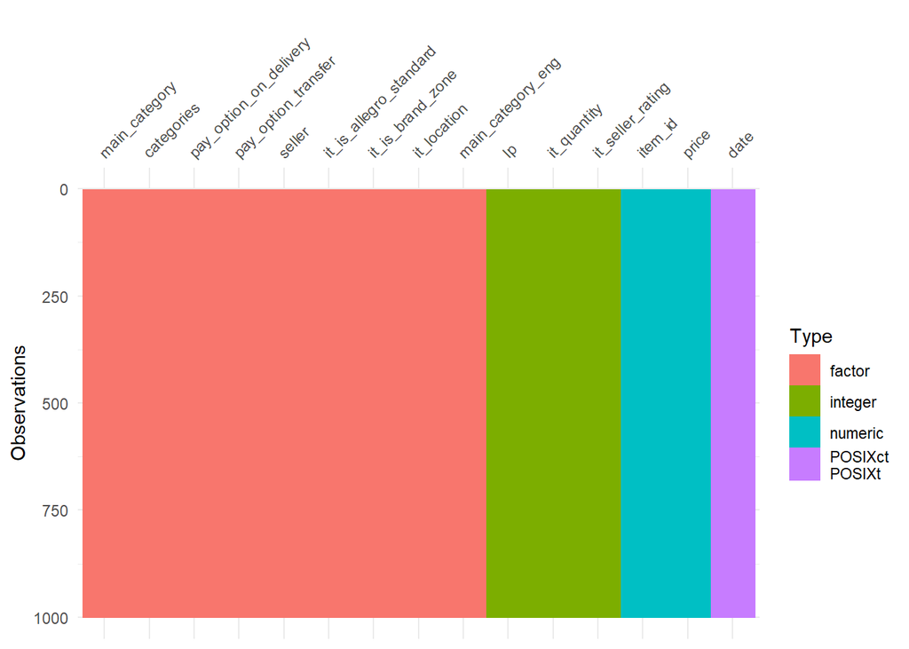

Jak widać mamy w większości do czynienia ze zmiennymi typu factor, kilka liczbowych, i jedna czasowa (po przekonwertowaniu w r).

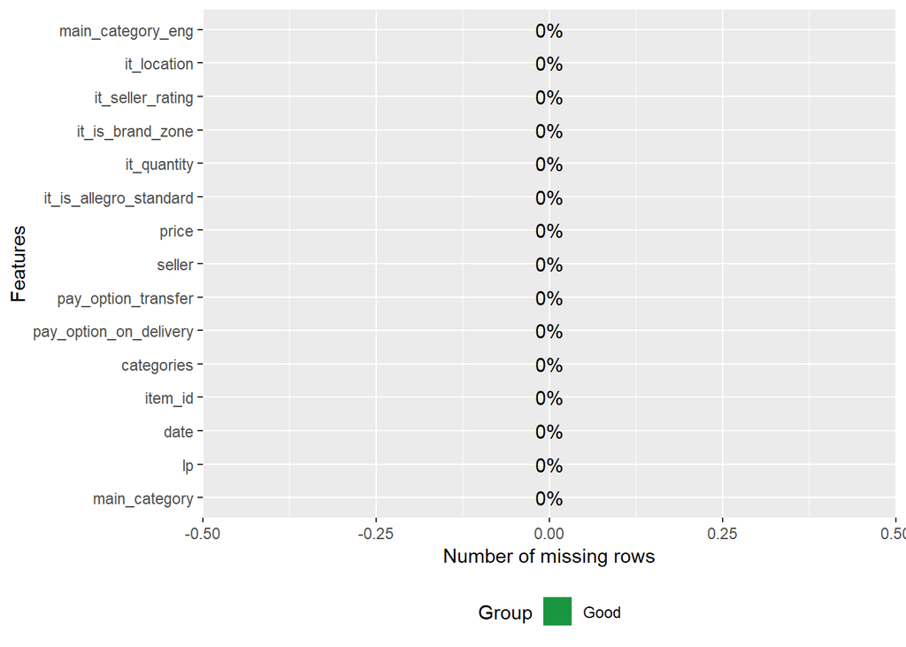

Wszystkie kolumny są kompletne.

# 1. Wykres korelacji

`## 6 features with more than 20 categories ignored! ## main_category: 27 categories ## date: 38953 categories ## categories: 9020 categories ## seller: 51064 categories ## it_location: 10056 categories ## main_category_eng: 27 categories`

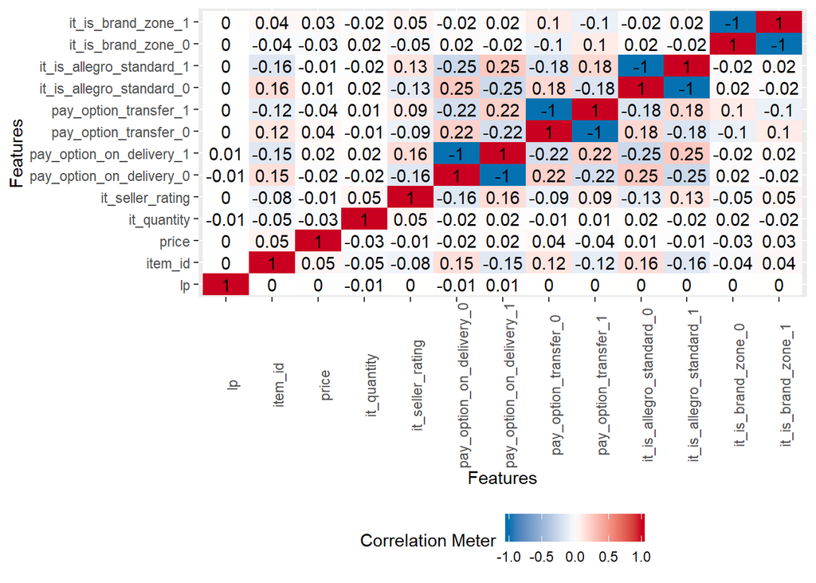

Powyższy wykres przedstawia wykres korelacji między różnymi zmiennymi. Szczególnie warto zwrócić uwagę na wyższą korelację między “it_is_allegro_standard” i “pay_option_on_delivery”, a także “pay_option_on_delivery” i “pay_option_transfer”.

# 2. Rozkład transakcji na przestrzeni dnia

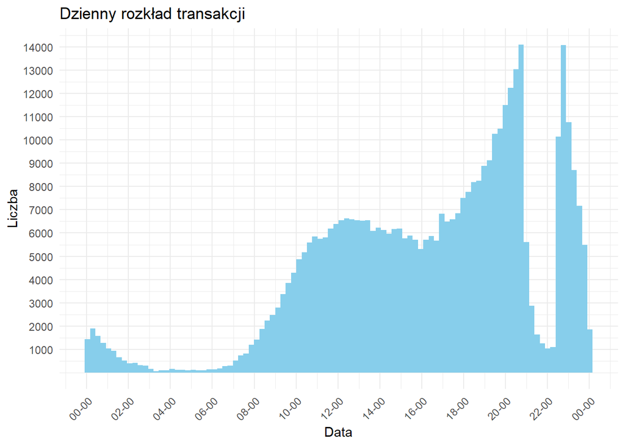

Na wykresie powyżej przedstawiono dzienny rozkład transakcji wykonanych na platformie allegro.pl dnia 3 kwietnia 2016 r. Widać ciekawą zależność, bądź też anomalię. Mianowicie można zaobserwować nagły spadek liczby transakcji między godzinami 21 i 23. O 23 liczba transakcji wraca do poziomu z godziny 21 i ponownie raptownie maleje.

Pozostają jeszcze dwa okresy w ciągu dnia, kiedy liczba transakcji zmalała. W okolicach 16 ludzie zazwyczaj wracają z pracy, być może spadek transakcji wtedy właśnie z tego wynika. Liczba transakcji spada oczywiście także nocą.

Największa liczba transakcji wykonywana jest w godzinach późnych.

# 3. Rozkład cen produktów

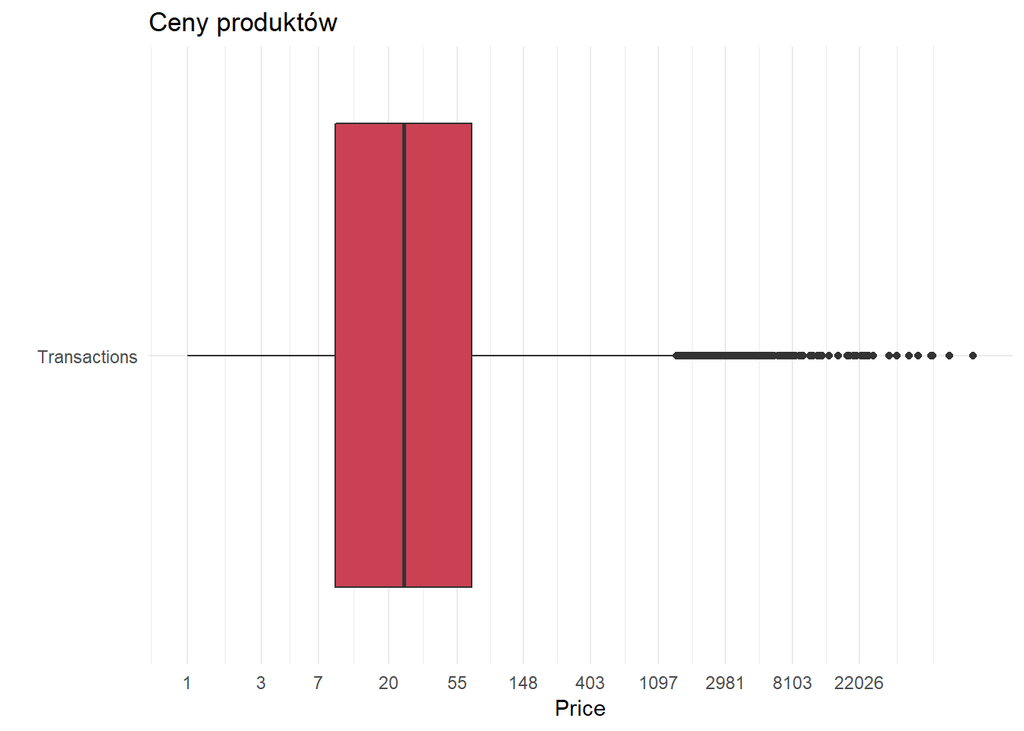

Wartość medialna wynosi 25zł, największa transakcja natomiast osiągnęła wartość aż 119000zł.

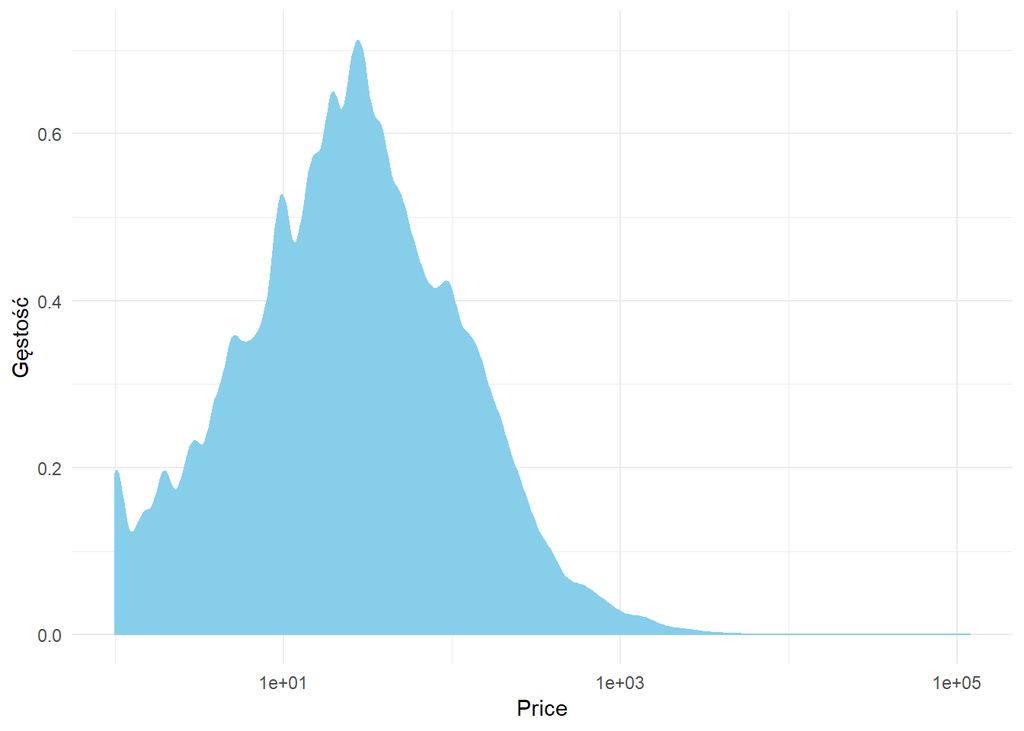

# 4. it_is_allegro_standard

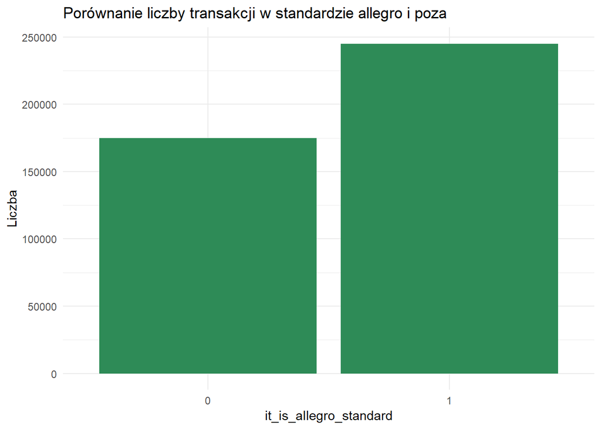

Jak widać większość transakcji wykonanych tego dnia jest w standardzie allegro, aczkolwiek wiele jest także transakcji poza standardem.

# 5. it_is_brand_zone

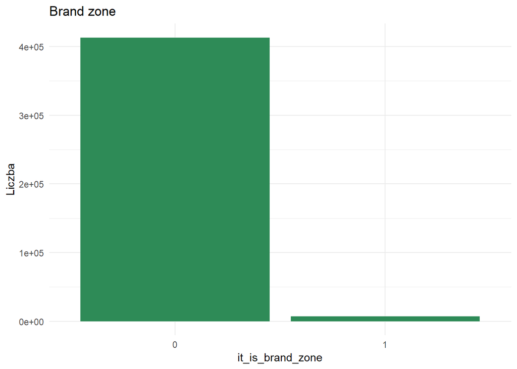

Jak widać przeważająca liczba transakcji była poza brand zone.

# 6. it_seller_rating

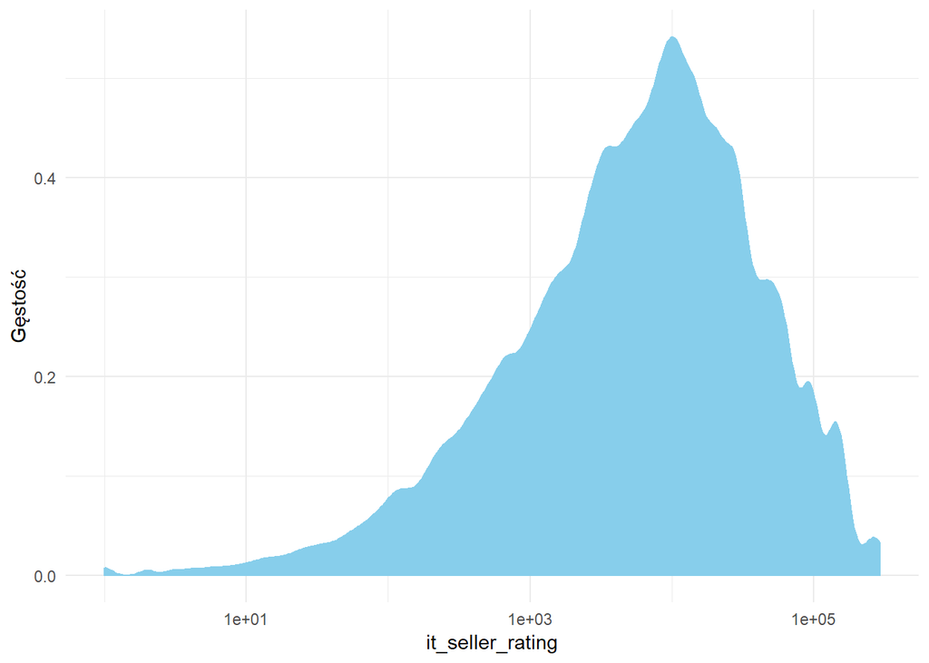

Warto zauważyć, że w większości na allegro aktywni są sprzedawcy bardzo popularni. Oznacza to, że allegro służy głównie firmom, a nie jednostkom.

# 7. Kategorie

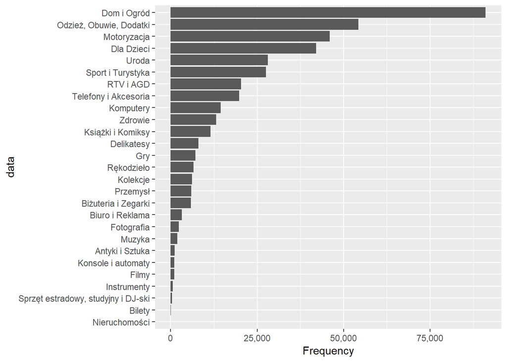

Tutaj widać porównanie liczby transakcji dla kategorii. Najwięcej transakcji miało kategorię Dom i Ogród. Co ciekawe motoryzacja także znalazła się dość wysoko.